# AEEM 3062

# HOMEWORK # 3

# 2022-2023 SPRING

### Name: Slade Brooks

### M#: 13801712

### DUE: 11.59 PM on 2/2/2023

## Problem 1

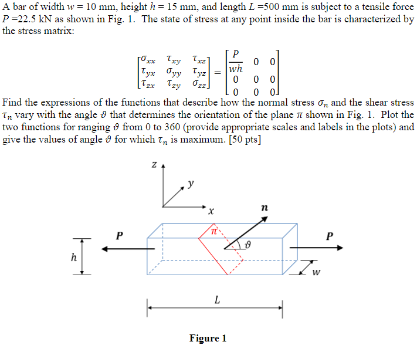

The stress matrices are given by: $\quad\sigma_{n} = \begin{bmatrix} \frac{P}{wh} & 0 & 0 \\ 0 & 0 & 0 \\ 0 & 0 & 0 \end{bmatrix} $

From the notes: $$ \sigma_{n}=t*n=\begin{bmatrix} n_{x} & n_{y} & n_{z} \end{bmatrix}*\begin{bmatrix} \sigma_{xx} & \tau_{xy} & \tau_{xz} \\ & \sigma_{yy} & \tau_{yz} \\ sim & & \sigma_{zz} \end{bmatrix}*\begin{bmatrix} n_{x} \\ n_{y} \\ n_{z} \end{bmatrix} $$

$$ \tau_{n}= t-(t*n)n = \begin{bmatrix} \sigma_{xx} & \tau_{xy} & \tau_{xz} \\ & \sigma_{yy} & \tau_{yz} \\ sim & & \sigma_{zz} \end{bmatrix} * \begin{bmatrix} n_{x} \\ n_{y} \\ n_{z} \end{bmatrix} - \sigma_{n}*\begin{bmatrix} n_{x} \\ n_{y} \\ n_{z} \end{bmatrix} $$

$n$ can never act in the y direction so $n_{y}$ is 0 $\\$ $ n_{x}$ and $n_{z}$ are based on $\theta$, with $n_{x}=\cos{\theta}$ and $n_{z}=\sin{\theta}\\$

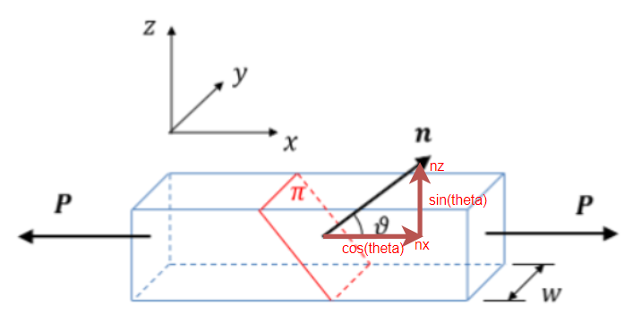

Substituting $n$ and $\hat\sigma$ into $\sigma_{n}$ gives: $ \quad\sigma_{n}=\begin{bmatrix} \cos{\theta} & 0 & \sin{\theta} \end{bmatrix}*\begin{bmatrix} \frac{P}{wh} & 0 & 0 \\ 0 & 0 & 0 \\ 0 & 0 & 0 \end{bmatrix}*\begin{bmatrix} \cos{\theta} \\ 0 \\ \sin{\theta} \end{bmatrix} $

Multiply the first two matrices using matlab.

$$ \sigma_{n}= \begin{bmatrix} \frac{P}{wh}\cos{\theta} & 0 & 0 \end{bmatrix}*\begin{bmatrix} \cos{\theta} \\ 0 \\ \sin{\theta} \end{bmatrix} $$

Multiply the remaining two matrices using matlab.

$$ \fbox{$\sigma_{n}=\frac{P\cos^{2}{\theta}}{wh}$} $$

Do the same for $\tau_{n}$ giving: $ \quad\tau_{n}= t-(t*n)n = \begin{bmatrix} \frac{P}{wh} & 0 & 0 \\ 0 & 0 & 0 \\ 0 & 0 & 0 \end{bmatrix} * \begin{bmatrix} \cos{\theta} \\ 0 \\ \sin{\theta} \end{bmatrix} - \frac{P\cos^{2}{\theta}}{wh}*\begin{bmatrix} \cos{\theta} \\ 0 \\ \sin{\theta} \end{bmatrix} $

$$ \tau_{n}=\begin{bmatrix} \frac{P\cos{\theta}}{wh} \\0\\0 \end{bmatrix} - \begin{bmatrix} \frac{P\cos^{3}{\theta}}{wh} \\ 0 \\ \frac{P\cos^{2}{\theta}\sin{\theta}}{wh} \end{bmatrix} $$

$$ \fbox{$\tau_{n}=\begin{bmatrix} \frac{P\cos{\theta} - P\cos^{3}{\theta}}{wh} \\ 0 \\ \frac{-P\cos^{2}{\theta}\sin{\theta}}{wh} \end{bmatrix}$} $$

$\tau_{n}$ at each angle equals the length of the vector $\tau_{n}$ to be found using Matlab's norm() function.

The two functions $\sigma_{n}$ and $\tau_{n}$ are plotted using Matlab's plot() function.

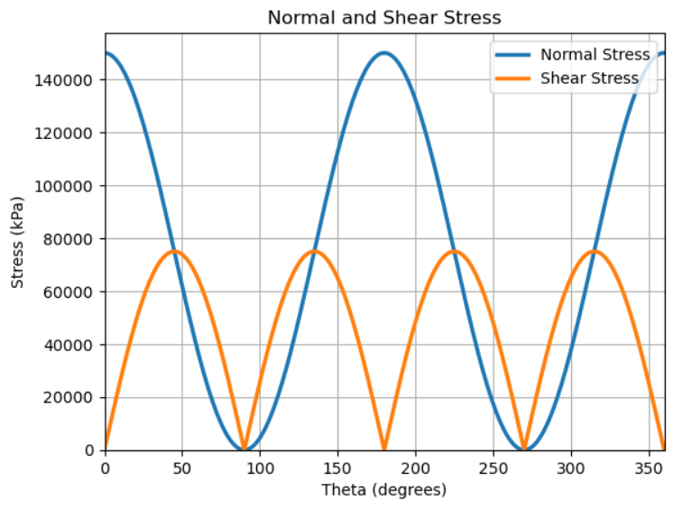

This shows that $tau_{n}$ has maximums at angles: $$\fbox{$\theta=45^{\circ},135^{\circ},225^{\circ},315^{\circ}$}$$

## Problem 2

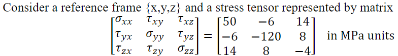

### Part A

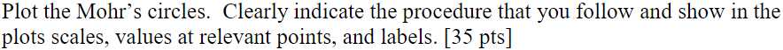

The locations of the values of the Mohr's circles $\sigma_{1},\sigma_{2},$ and $\sigma_{3}$ are the eigenvalues of the stress tensor $\sigma$.

Using Matlab's eig() function we can get the eigenvalues of $\sigma$.

Then we plot these points on a graph. The largest point becomes $\sigma_{1}$, the next largest is $\sigma_{2}$, and so on. Then, the Mohr's circles are plotted. This is done by plotting one circle with a diameter from $\sigma_{1}$ to $\sigma_{3}$, one from $\sigma_{1}$ to $\sigma_{2}$, and one from $\sigma_{2}$ to $\sigma_{3}$.

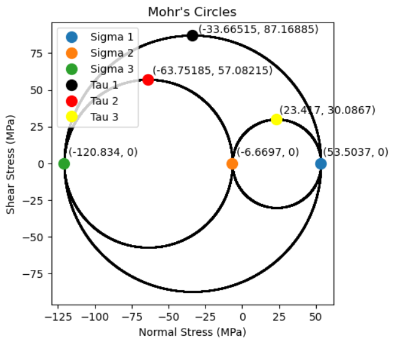

### Part B

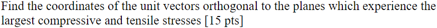

The largest compressive stress is found at $\sigma_{3}$ since negative normal stress is compressive. Using Matlab's eig() function on the stress tensor $\sigma$ we can determine the corresponding eigenvector for $\sigma_{3}=-120.834$:

$$ \fbox{$\begin{bmatrix} -0.0410 \\ -0.9965 \\ 0.0731 \end{bmatrix}$} $$

$$ \fbox{$\begin{bmatrix} -0.9721 \\ 0.0229 \\ -0.2335 \end{bmatrix}$} $$